# Data Visualization with ggplot2

From Points and Bars to Boxplots and Maps in ggplot2

Bogdan G. Popescu

bogdan.popescu@johncabot.edu

John Cabot University

## Learning Outcomes

By the end of this lecture, you will be able to:

- Understand the logic of the Grammar of Graphics.
- Create plots in R using ggplot2.
- Choose the right geom for your data:
  - points
  - bars
  - lines
  - boxplots
  - density plots
  - maps

# Purpose of Visuals

## Why Visuals?

### Numbers vs Visuals

Would you rather read this?

| Country | LifeExpectancy |
| --- | --- |
| Monaco | 77.25278 |
| Andorra | 77.04861 |
| San Marino | 76.88056 |
| Guernsey | 76.71944 |
| Israel | 75.49722 |

…or see this?

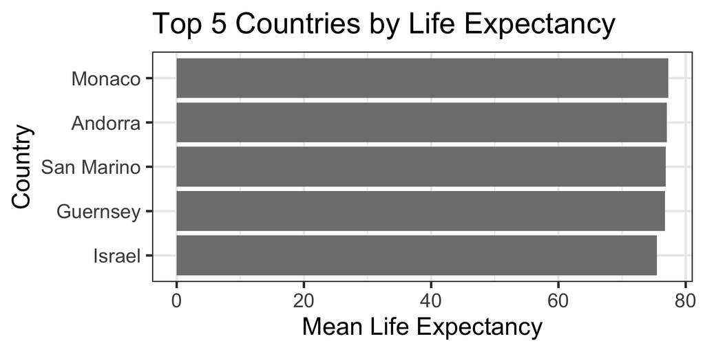

## Why Visuals Matter

Visuals are powerful because they:

- Reveal patterns we miss in tables
- Help us explain results clearly
- Persuade others more effectively

# Intro to ggplot2

## The ggplot2 library in R

R can help us achieve great visualizations with the help of `ggplot2`

[figure not shown]

## The ggplot2 library in R

R can help us achieve great visualizations with the help of `ggplot2`

[figure not shown]

## The ggplot2 library in R

R can help us achieve great visualizations with the help of `ggplot2`

[figure not shown]

## The Essentials

### Grammar of Graphics

- At the most basic level we have:
  - data
  - geometries
  - aesthetics
- Optional layers include:
  - facets
  - coordinates
  - annotations
  - themes, etc.
- We can add them together in `ggplot()` with `+`

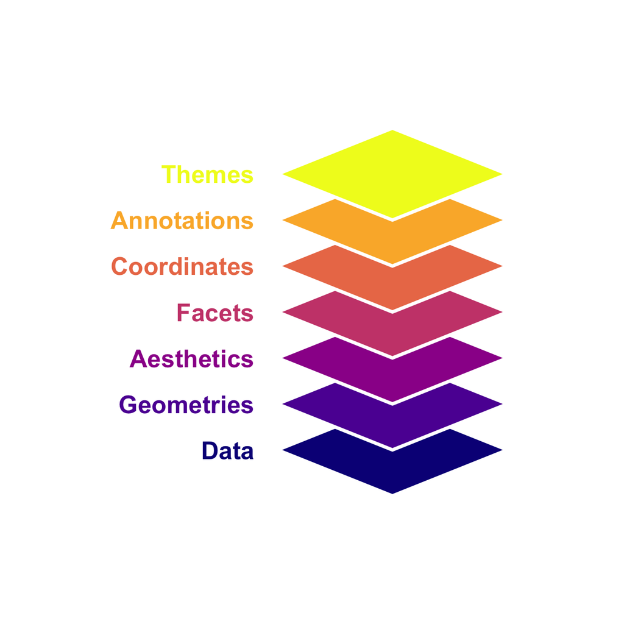

## Data Cleaning

### Preparing the Data

Before we use `ggplot`, our data has to be tidy. This means:

- Each variable is a column
- Each observation has its own row
- Each value has its own cell

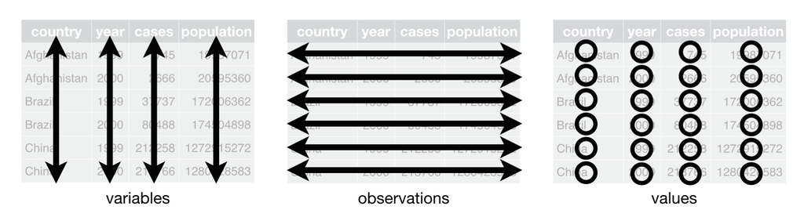

# Simple Geoms

## Simple Geoms

### Geometries

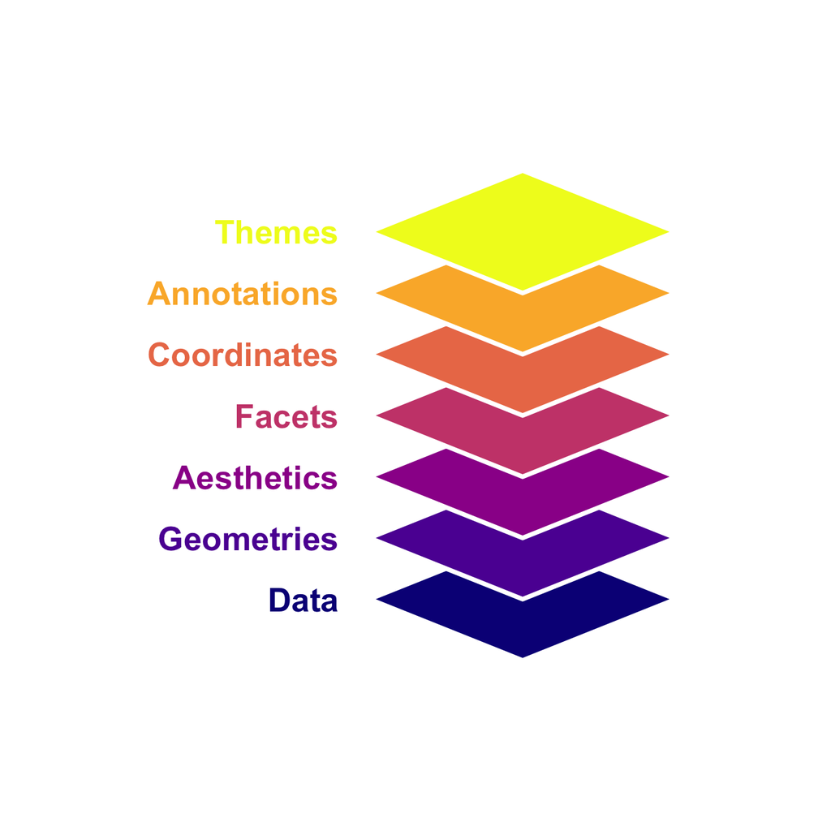

## Simple Geoms

### Geometries

- Geoms are the “shapes” your data takes on a graph.
- Example:
  - points (geom_point) make a scatterplot
  - bars (geom_bar) make a bar chart
  - lines (geom_line) make a line graph.

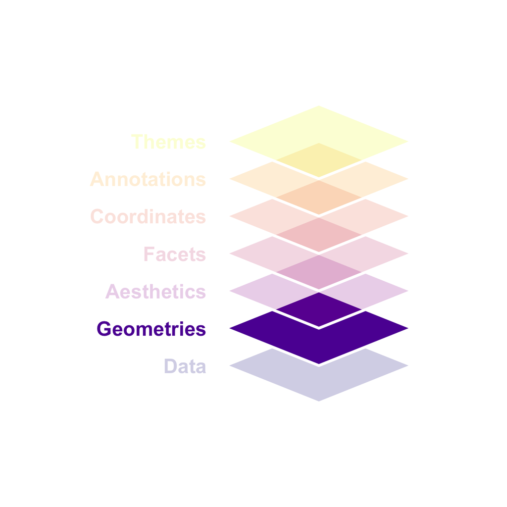

## Simple Geoms

### Examples

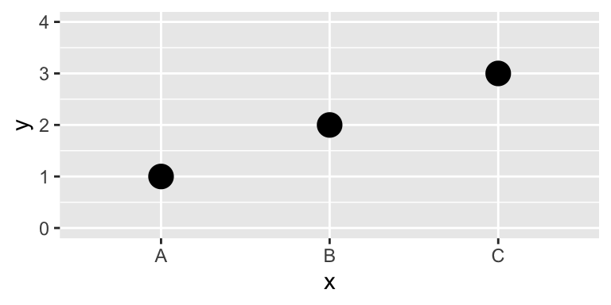

`geom_point`

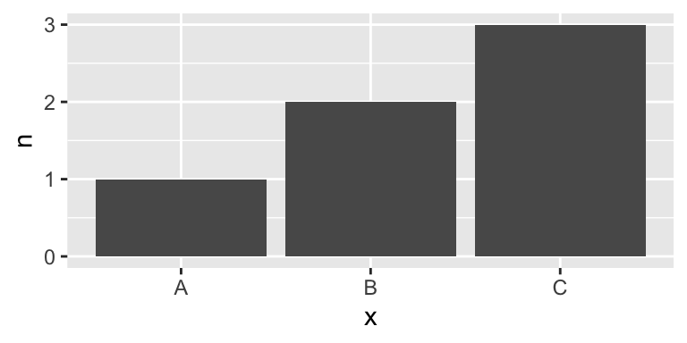

`geom_col`

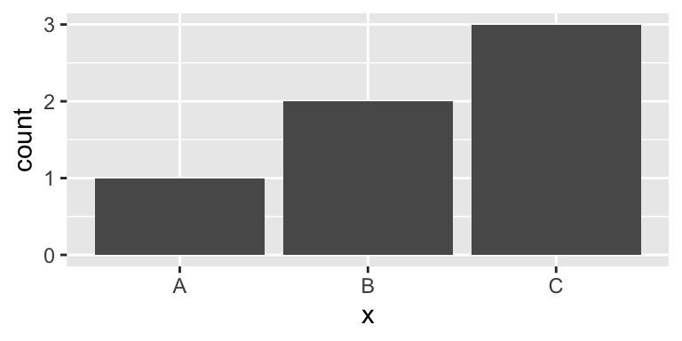

`geom_bar`

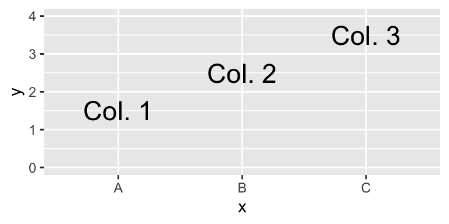

`geom_text`

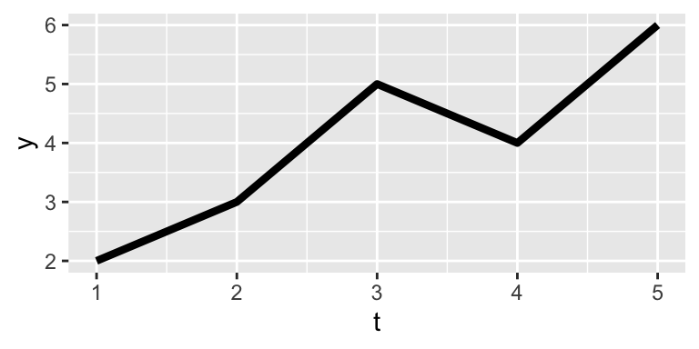

`geom_line`

## Simple Geoms

### Reference

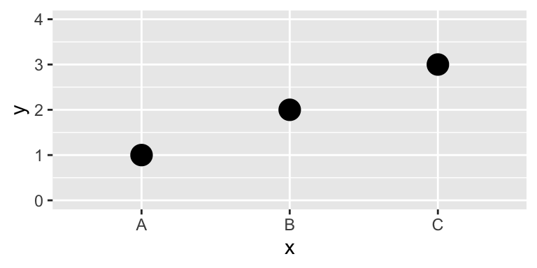

`geom_point`

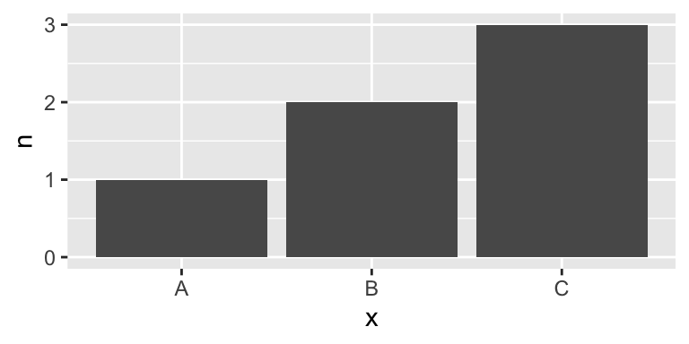

`geom_col`

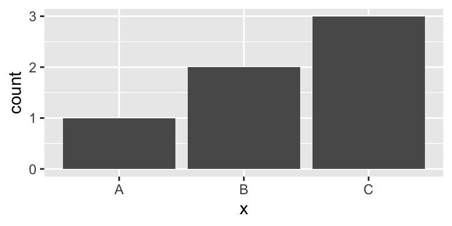

`geom_bar`

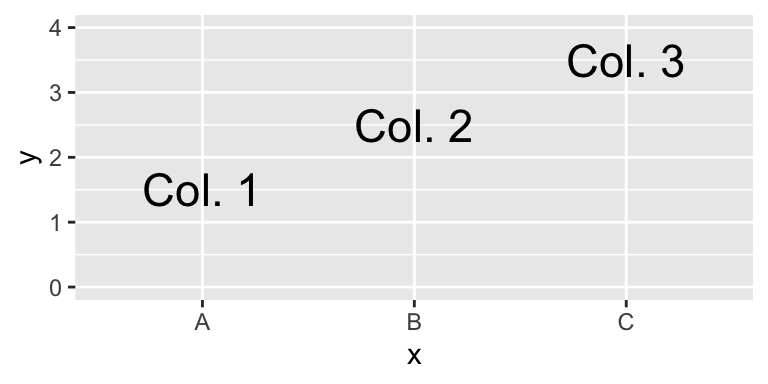

`geom_text`

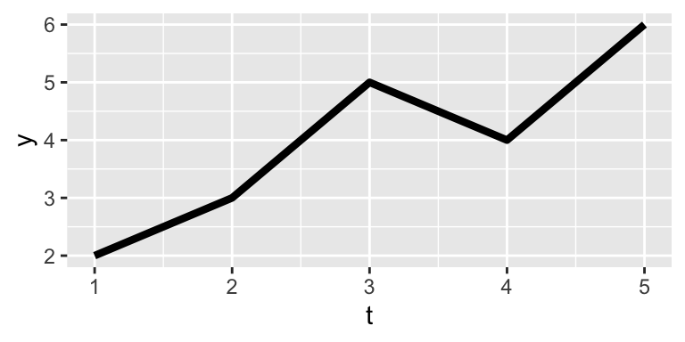

`geom_line`

[output not shown]

## Simple Geoms

### `geom_point`

Imagine we have data about 9 countries that records their level of democracy from -10 to +10 (x-axis) and their GDP per capita in $1,000s (y-axis).

```r
eg1 <- data.frame(
  democracy = c(-8, -7, -5, -3, 0, 2, 5, 8, 9),   # democracy score
  gdp = c(2, 9, 4, 7, 8, 20, 15, 25, 27)  # GDP per capita in $1000s
)
```